# 7.Week_Lectures Interactive Data Visualization, The Shiny App

Edda Brandes

´2022-06-07´

# 1 Building interactive web apps with the R package Shiny

´library(shiny)´

Applied Data Analysis and Visualization, presented by Hanne Oberman

# 2 The shiny framework

*Why use ´shiny´?*

Make your R workflows:

- interactive (point and click style)
- reproducible for non-coders
- look instantly professional

## 2.1 The template app

Creating a new R Shiny app:

The easiest way to create a new Shiny Application, is through the RStudio GUI. This can be done in one of two ways:

- Option 1: New File -> R Markdown… -> Select Shiny, Ticking Shiny Document
- Option 2: New File -> Shiny Web App… -> Select either to produce this as a Single File (app.R) or Multiple Files (ui.R/server.R).

For this practical we recommend creating a Shiny Application using the Multiple File format (ui.R/server.R).

To run the app, click Run App in the top right of your main coding panel. This should either produce a pop-out window for this application, if this does not happen, either check your viewer panel (in the bottom right panel usually) or the Console for any errors.

## 2.2 How does the ´shiny´ app work?

We have two compoenents, the user interface (UI) and the server.

*UI:*

- visible, interactive part, e.g. a web app or a dashboard

The names of these tabs give a quite clear indicate of what they do, the ui.R tab provides a schematic for how the application will be presented to the individual using the application. Within the Old Faithful Geyser example, you can observe that this provides details such as layout through the functions:

- titlePanel(): Providing a title
- sidebarLayout() & sidebarPanel(): which provide a side bar & layout
- mainPanel(): provides a main panel This is only one example of the layouts which an R Shiny application can take, with more examples being found in Chapter 3.4 in Mastering Shiny. However for this tutorial we will be using this layout as it is one which is most commonly used.

Although not formally defined, it is traditional that your parameter changing aspects, so inputs (for example slider bars, drop down boxes etc), are located in the sidebar with any outputs (graphs, tables etc) being located in mainPanel. Although not formally defined, this allows the majority of your application’s visual space to be used to display your output rather than any input.

To add or remove component from your sidebar or mainPanel use them as you would any other R function, and add or remove components as you need them.

*Server:*

- invisble processig part
- e.g. your own computer or shinyapps.io

So what about the server.R tab? This contains everything which should be done in the background of the application. Whether completing any statistical analysis, plotting any graphs or any other code which acts is required for the output.

Everything within the shinyserver can be classified under two components, either inputs or outputs.

- As inputs suggest, these take information which is Input from the ui.R tab, and moves it to the server.R tab.
- Whereas the output, does the reverse and allows the calling of information from the server.R tab to the ui.R tab.

In the Old Faithful Geyser example, we can see that:

- The input here is seen to classify the number of bins (input$bins)
- The output defines the entire histogram plotted (distplot).

*What Shiny does is to connect these two components to each other:*

```
ui <- # some code to generate the UI
server <- # some code to generate the server
shinyApp (ui = ui, server = server)
```

## 2.3 What does shiny offer?

- collection of wrapper functions to write “app languages”:
  - geared toward R users who have zero experience with web development
  - no knowledge HTML / CSS/ JavaScript is required
  - but you can extend it with CSS themes, htmlwidgets and JavaSchript actions
- developed by RStudio, so documentation & support is garanteed

## 2.4 Starting point

1. Create a empty frame

```
library(shiny)
ui <- fluidPage()
server <- function(input, output) {}
shinyApp (ui= ui, server = server)
```

2. Before rush into coding & building a ´shiny´ app, think about:
- What is the app aimed at?
- Who are the end users of your app? Are they tech-literate? Which menu e.g. would fit for them?
- In what context will the app be used? on what machines (e.g. because screen size differ)

# 3 The UI

Tips for building the front-end of the app:

- work on general appearance first, anything that does not rely on computation (e.g. tabls, inputs, outputs);
- use mock data and/or text (build an `psum-app`)
- make the app self-evident: the main usage of the app should not require reading any manual

## 3.1 The title with ´titlePanel()´

```
ui<- fluidPage(
  titlePanel("Palmer penguins")
)
```

- adds a visible big title-like text to the top of the page
- sets the “official” title of the web page( i.e., displayed at the name of the tab in the browser)

## 3.2 Add further text with wrappers around HTML functions

Insert text with functions, so the text is formatted:

```
h1() # top-level header
h2() # secondary header
strong() # bold
em() # italicized
br() # line break
img() # image
a() #hyperlink
```

*Note: html works as well!*

Example:

```
ui<- fluidPage(
  titlePanel("Palmer penguins"),
"An",
em("interactive"),
br(),
strong("visualization")
)
```

## 3.3 Adding a layout

simple sidebar layout, very common interactive layout:

- provides two-column layout witha smaller sidebar and larger main panel
- visually seperates the input and output of the app
- very handy, because it is also a visual hint for users, that they can interact with the input sidebar

```
ui<- fluidPage(
  titlePanel("Palmer penguins"),
  sidbarLayout(
    sidebarPanel("[inputs"),
    mainPanel("[outputs]")
  )
)
```

## 3.4 Add input elements

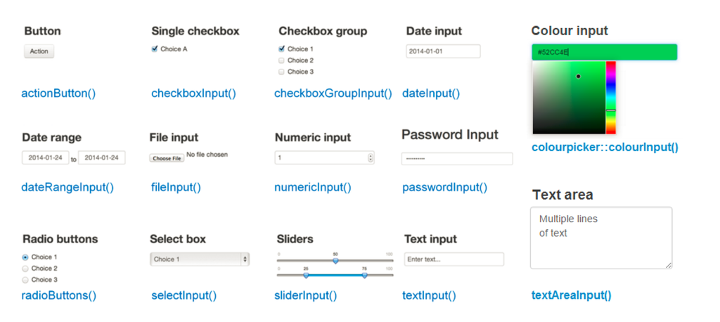

very common:

´selectInput()´ creates drop down menu (number of bins)

´sliderInput()´ creates numeric scale (bandwidth adjustment)

**Example: Which function would suit an input element for the variable ´island´?**

```
ui<- fluidPage(
  titlePanel("Palmer penguins"),
  sidbarLayout(
    sidebarPanel(
      radioButtons( #which type of input element?
        inputId = "location", #unqiue name of input Id
        label = "Location", #name how the input is displayed in ui
        choices=c("Biscoe", "Dream", "Torgersen")) #choices to click in the ui
    ),
    mainPanel("[outputs]")
  )
)
```

All input functions have the same first two arguments:

- ´inputId´, the name by which ´shiny´ will refer to this input when you want tot retrieve its current value → must have unique InputID, otherwise the app will not work properly
- ´label´ specifies the text displayed righ above the input element

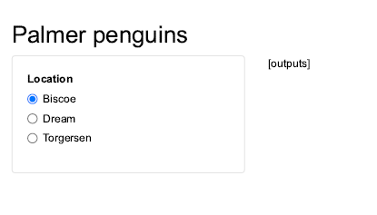

**Example: lets add an input element for the varliable ´body_mass_g´ as well

```
ui<- fluidPage(
  titlePanel("Palmer penguins"),
  sidbarLayout(
    sidebarPanel(
      radioButtons( #which type of input element?
        inputId = "location", #unqiue name of input Id
        label = "Location", #name how the input is displayed in ui
        choices=c("Biscoe", "Dream", "Torgersen")), #choices to click in the ui
    sliderInput("weight", #InputID
                "Weight", #Label
                min=2, #minimum range of scale
                max= 7, #maximum range
                value=c(3,5), #default for the slider
                post="kg") #adding the unit of measurement
    ),
    mainPanel("[outputs]")
  )
)
```

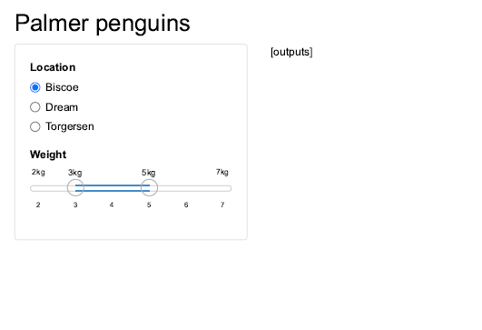

## 3.5 Adding an output element

Outputs are shown in the UI, but created on the server side. That´s why we add placeholders for the outputs in the UI.

Placeholders:

- Determine where an output will be
- give outputs a unique ID to link it to the server won´t actually show anything, yet
- this is the case, why our app is still empty, because we have no data mapped to the ui yet, that happens in the server component, so if we run this, we will not see a table or a scatter plot

Let´s add a figure and as output in our app:

```
mainPanel(
  plotOutput("scatterplot"), #add scatterplot as output
  br(), #insert some line breakes
  br(),
  tableOutput("descriptives") #add table with descripties
)
```

all in one the function looks like this:

```
ui<- fluidPage(
  titlePanel("Palmer penguins"),
  sidbarLayout(
    sidebarPanel(
      radioButtons( #which type of input element?
        inputId = "location", #unqiue name of input Id
        label = "Location", #name how the input is displayed in ui
        choices=c("Biscoe", "Dream", "Torgersen")), #choices to click in the ui
    sliderInput("weight", #InputID
                "Weight", #Label
                min=2, #minimum range of scale
                max= 7, #maximum range
                value=c(3,5), #default for the slider
                post="kg") #adding the unit of measurement
    ),
    mainPanel(
      plotOutput("scatterplot"), #add scatterplot as output
      br(), #insert some line breakes
      br(),
      tableOutput("descriptives") #add table with descriptives
    )
  )
)
```

# 4 The Server

- requires input and output IDs from the UI (except for apply)
- builds output objects via ´render… ()´ functions → all outputs that are interactive are created with the render function! Because render take a list of input and output Ids and make an interactive output list
- save the generated output into an output list

## 4.1 building a static output

Example: a plot like this

```
ggplot(penguins,
aes(flipper_length_mm, bill_length_mm, color= species))+
geom_point()+
geom_smooth(method="lm", se = FALSE)+
scale_color_palmer()+
labs(title"Flipper and bill length by species(static)")
```

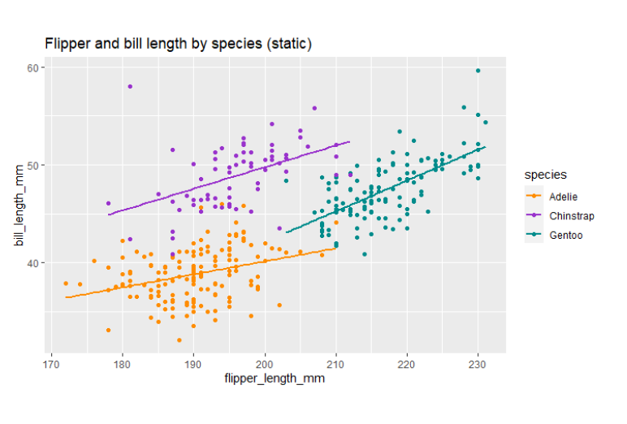

## 4.2 Add the static output to server function

We define an output, the plot and that output displayed is conditional to the input, we link now the input to the output!

```
server <- function(input, output){
  output$scatterplot <- renderPlot({
  filtered <- penguins %>%  #create a filter function
  filter(island == input$location, #filter location
  body_mass_g >= input$weight[1] * 1000, #filter min binwidth
  body_mass_g <0 input$weight[2] * 1000 #filter max binwidth
  )
  filtered %>% #filter plot with filter function
    ggplot(penguins,
           aes(flipper_length_mm, bill_length_mm, color= species))+
      geom_point()+
      geom_smooth(method="lm", se = FALSE)+
      scale_color_palmer()+
      labs(title"Flipper and bill length by species(static)")
    })
}
```

Same for the table:

```
output$descripitives <- renderTable({
filtered <- penguins %>%  #create a filter function
  filter(island == input$location, #filter location
  body_mass_g >= input$weight[1] * 1000, #filter min binwidth
  body_mass_g <0 input$weight[2] * 1000 #filter max binwidth
  )
filtered %>%
  group_by(species) %>%
  summarise(across(c(bill_length_mm, flipper_length_mm), mean, na.rm = TRUE))
})
```

also here we integrate a filter, to filter the input and the output together here we have twice the filter function! We should use a function!

# 5 Reactivity

Reactivity enables your outputs to react to changes in inputs

on the most basic level, it means, that when the value of a variable x changes, anything that relies on x get re-evaluated automatically.

Example:

```
x <- 5
y <- x+1
x<- 10
```

we have reactivity in our shiny app, because of automatic updating and the interactive part. So in the following code, y stays 6, although we have assigned a 10 to the x. Only if run the y again, it would change.

In shiny we reactivity, so y would change automatically to 11.

In ´shiny´ we use this reactivity implicitly, because if the input changes, conditional to that the output changes. In the latter example, we do this with the ´filtered´:

```
filtered <- penguins %>%  #create a filter function
  filter(island == input$location, #filter location
  body_mass_g >= input$weight[1] * 1000, #filter min binwidth
  body_mass_g <= input$weight[2] * 1000 #filter max binwidth
  )
```

Whenever one of the inputs changes, our outputs change with it. But, this part of code is duplicated, because we didn´t use a reactive variable. In the former, we have used ´filtere´ twice, we have duplicated code, that is not good practice, because increase the chance to bug!

Avoid that with defining a **reactive variable**, that will hold the filtered data set & using that variable in the ´render …()´ function.

What happens in doing this?

- the input variables changes
- ´shiny´ looks at the reactive(s) depended on weight and location
- ´filtered()´ is re-evaluated
- ´shiny looks at the reactive8s) that depend on ´filtered()´
- the two ´render…() functions are re-executed
- the plot and the table are updated

this can be visualized in a dependency tree, to show what value depends on what other value.

## 5.1 Final App

```
server <- function(input, output){
  filtered <- reactive({ #define a reactive variable
    penguins %>% #data set
      filter(island == input$location, #filter location input
             body_mass_g >= input$weight[1] * 1000, #filter min input
             body_mass_g <= input$weight[2] * 1000 #filter max input
      )
  })
  output$scatterplot <- renderPlot({
  filtered %>% #use the reactive variable
    ggplot(penguins, # define the scatterplot
           aes(flipper_length_mm, bill_length_mm, color= species))+
      geom_point()+
      geom_smooth(method="lm", se = FALSE)+
      scale_color_palmer()+
      labs(title="Flipper and bill length by species(static)")
    })
  output$descripitives <- renderTable({
filtered %>% #use the reactive variable again
  group_by(species) %>%
  summarise(across(c(bill_length_mm, flipper_length_mm), mean, na.rm = TRUE))
    })
}
```

**Note: For good practice, you store the scatterplot and the table in an extra object and only insert the object!*+